# Análisis y predicción de una serie temporal

Hassan Chafi Xavier

23/2/2022

## Preparación de las herramientas de trabajo

Como en todo proyecto, lo primero que comenzaré haciendo es cargar las librerías que voy a utilizar y cargar los datos con los que se pretende trabajar.

```r
# Cargo librerías
library(readxl)
library(ggplot2)
library(forecast)
library(dplyr)
```

```r
# Lectura del archivo
datos <- read_xlsx("C:/Users/96has/Documents/NTIC/7. Documentación minería de Datos y Modelización Predictiva - Juana Mª Alonso-20220117/Tarea minería de datos y modelización predictiva - Juana Mª/Evaluacion/PernoctacionesApartTur.xlsx")
```

### 1. Introducción: Presentación de la serie a analizar. (1)

La serie que se va a analizar a continuación se corresponde con las pernoctaciones realizadas por ciudadanos tanto nacionales como extranjeros en apartamentos turísticos de todas las localizaciones del territorio nacional español desde enero de 2005 hasta diciembre de 2017 para lo que se tienen el número total de esas pernoctaciones en datos mensuales. Los datos han sido extraídos del Instituto Nacional de Estadística (INE) donde hay disponibles datos referentes al sector servicios en España.

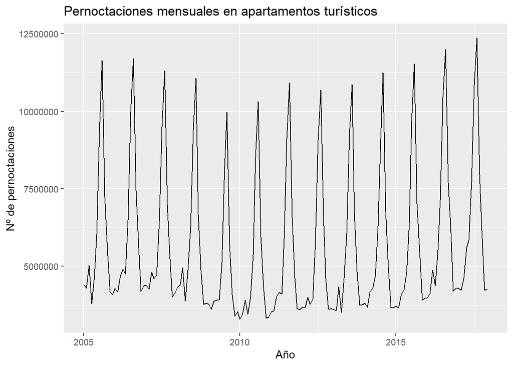

```r
# Representación de la serie
pernoctaciones <- ts(datos[,-1], start = c(2005, 1), frequency = 12)
autoplot(pernoctaciones) + ggtitle("Pernoctaciones mensuales en apartamentos turísticos") + xlab("Año") + ylab("Nº de pernoctaciones")
```

### 2. Representación gráfica y descomposición estacional (si tuviera comportamiento estacional). (1.5)

La tabla con los coeficientes de estacionalidad que se observan a continuación se interpretan de modo que podemos afirmar que en el mes de agosto se registran un 100% más de pernoctaciones que en la media del año y en el mes de noviembre se registran un 68% de la media del total de pernoctaciones del año (un 32% menos que la media del total de pernoctaciones del año).

```r
# Descomposición estacional de la serie
pernoctaciones_descomp <- decompose(pernoctaciones, type = c("multiplicative"))
knitr::kable(pernoctaciones_descomp$figure, digits = 2, caption = "Coeficientes de estacionalidad")
```

Coeficientes de estacionalidad

| x |
| --- |
| 0.69 |
| 0.69 |
| 0.78 |
| 0.75 |
| 0.82 |
| 1.11 |
| 1.67 |
| 2.00 |
| 1.22 |
| 0.90 |
| 0.68 |
| 0.69 |

La representación gráfica de la descomposición estacional de la serie según el modelo multiplicativo muestra la tendencia que sigue la serie, el componente estacional y el componente irregular.

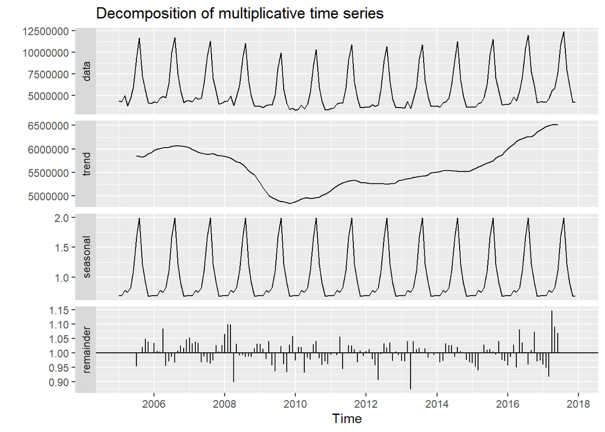

```r
# Representación gráfica de componentes
autoplot(pernoctaciones_descomp, ts.color = "blue")
```

Podemos observar también un gráfico donde simultáneamente se representan la serie observada, la tendencia de la serie y la serie con el ajuste estacional para exhibir las variaciones debidas a la época del año.

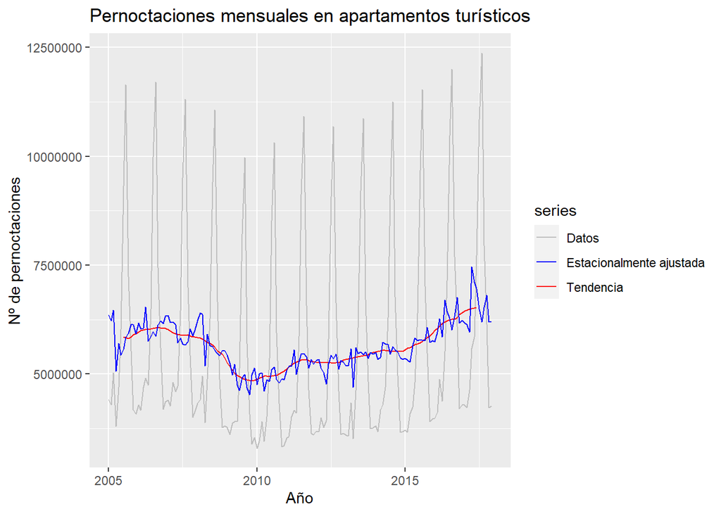

```r
# Representación gráfica de la tendencia y la serie ajustada estacionalmente
autoplot(pernoctaciones, series = "Datos") +
  autolayer(trendcycle(pernoctaciones_descomp), series = "Tendencia") +
  autolayer(seasadj(pernoctaciones_descomp), series = "Estacionalmente ajustada") +
  xlab("Año") + ylab("Nº de pernoctaciones") +
  ggtitle("Pernoctaciones mensuales en apartamentos turísticos") +
  scale_colour_manual(values = c("gray", "blue", "red"),
                      breaks = c("Datos", "Estacionalmente ajustada", "Tendencia"))
```

El mes de agosto del año 2017 es el registro donde se alcanzó el mayor número de pernoctaciones en apartamentos turísticos de toda la observación de la serie representada.

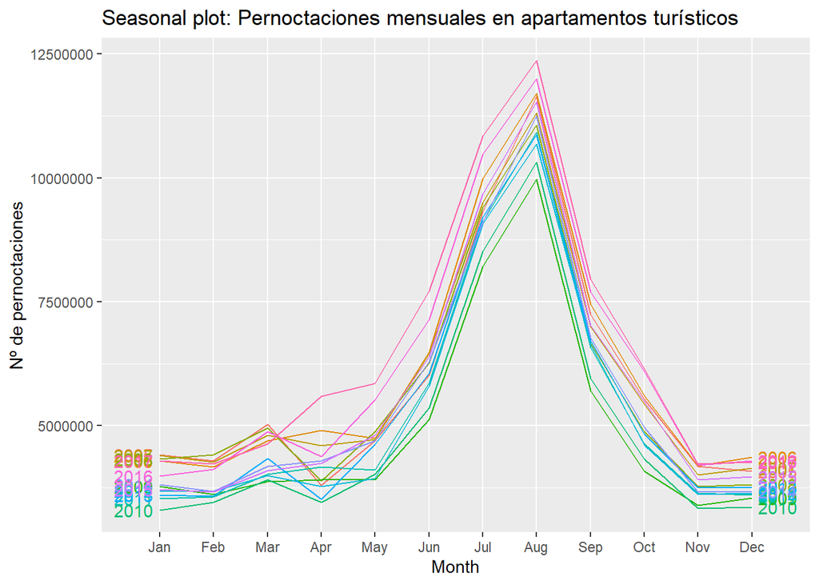

```r
# Representación gráfica de los valores para cada año
ggseasonplot(pernoctaciones, year.labels = TRUE, year.labels.left = TRUE) +
  ylab("Nº de pernoctaciones") + ggtitle("Seasonal plot: Pernoctaciones mensuales en apartamentos turísticos")
```

### 3. Para comprobar la eficacia de los métodos de predicción que vamos a hacer en los siguientes apartados reservamos los últimos datos observados (un periodo en las series estacionales o aproximadamente 10 observaciones) para comparar con las predicciones realizadas por cada uno de los métodos. Luego ajustamos los modelos sobre la serie sin esos últimos datos en los siguientes apartados

```r
# Reservo los datos de los meses correspondientes al último año
pernoctaciones_reserv <- window(pernoctaciones, end = c(2016, 12))
```

### 4. Encontrar el modelo de suavizado exponencial más adecuado. Para dicho modelo, representar gráficamente la serie observada y la suavizada con las predicciones para un periodo que se considere adecuado. (2)

Dado que la serie tiene estacionalidad, el modelo de suavizado exponencial más adecuado será el de Holt-Winters multiplicativo ya que la incidencia de la estacionalidad **NO** aumenta con el tiempo. Se han calculados los intervalos de predicción para unos niveles de confianza del 80% y del 95%. Esto indica que con un 80% de posibilidades los resultados correspondientes a la realidad se encontrarán dentro de la zona azul más intensa en el siguiente gráfico y que con un 95% se encontrará en la zona azul menos intensa en el gráfico. Se han calculado las predicciónes para un año más al último observado en la serie original.

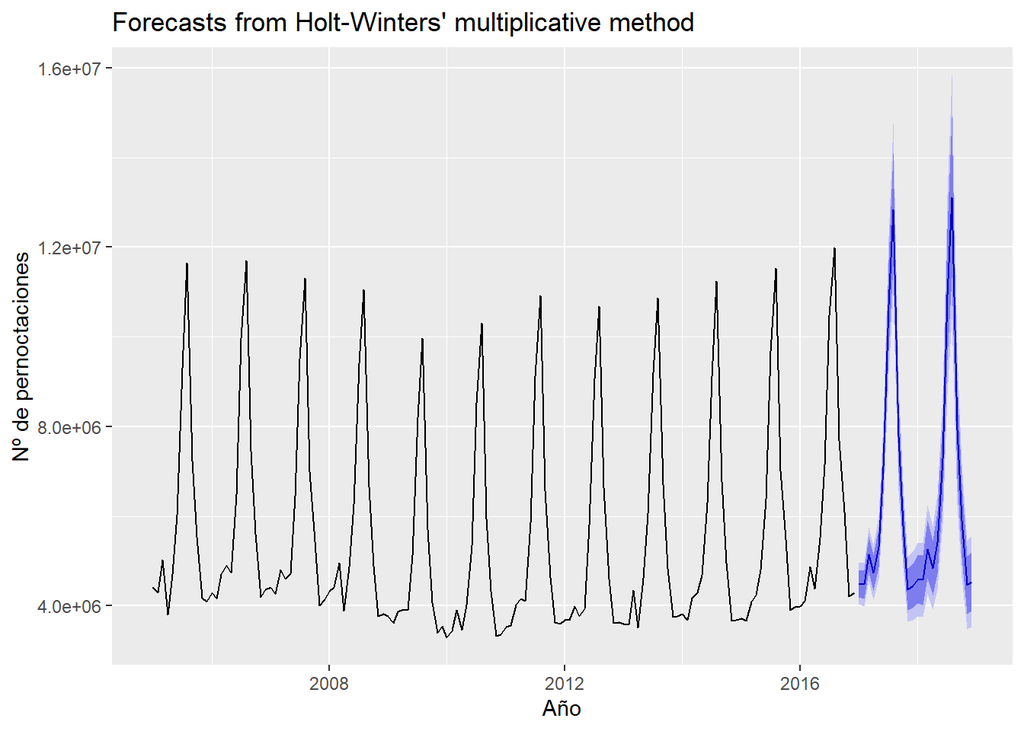

```r
# Modelo de Holt-Winters
modelo <- hw(pernoctaciones_reserv, seasonal = "multiplicative", level = c(80, 95))
autoplot(modelo) + xlab("Año") + ylab("Nº de pernoctaciones")
```

Aquí se representan la serie observada y la serie suavizada por el método de Holt-Winters.

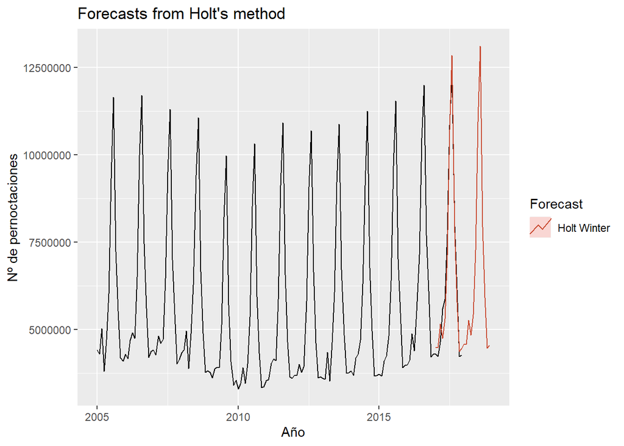

```r
# Representación de la serie observada y la suavizada
autoplot(pernoctaciones) +
  autolayer(modelo, series = "Holt Winter", PI = FALSE) +
  ggtitle("Forecasts from Holt's method") + xlab("Año") + ylab("Nº de pernoctaciones") +
  guides(colour = guide_legend(title = "Forecast"))
```

A continuación, se pueden observar las predicciones exactamente cuantificadas junto con el intervalo de predicción.

```r
# Las predicciones que arroja el modelo
print(modelo)
```

```
##          Point Forecast    Lo 80    Hi 80    Lo 95    Hi 95
## Jan 2017        4493162  4193499  4792825  4034866  4951458
## Feb 2017        4480979  4158238  4803720  3987389  4974569
## Mar 2017        5152558  4755938  5549178  4545980  5759136
## Apr 2017        4739687  4352860  5126515  4148086  5331289
## May 2017        5307834  4851399  5764270  4609777  6005892
## Jun 2017        7124689  6482412  7766966  6142410  8106968
## Jul 2017       10710079  9702151 11718008  9168586 12251573
## Aug 2017       12837924 11581057 14094792 10915711 14760137
## Sep 2017        7771183  6982062  8560304  6564327  8978039
## Oct 2017        5787293  5179330  6395256  4857493  6717093
## Nov 2017        4371719  3897664  4845773  3646715  5096722
## Dec 2017        4448008  3951116  4944900  3688077  5207939
## Jan 2018        4590714  4058182  5123245  3776278  5405150
## Feb 2018        4578091  4033051  5123131  3744524  5411658
## Mar 2018        5264025  4621695  5906356  4281666  6246385
## Apr 2018        4842040  4237202  5446877  3917021  5767058
## May 2018        5422251  4729653  6114849  4363013  6481489
## Jun 2018        7277996  6328335  8227658  5825614  8730379
## Jul 2018       10940127  9483208 12397046  8711961 13168292
## Aug 2018       13113187 11332408 14893967 10389720 15836655
## Sep 2018        7937513  6839173  9035852  6257748  9617278
## Oct 2018        5910942  5078132  6743752  4637269  7184615
## Nov 2018        4464958  3824850  5105066  3485998  5443918
## Dec 2018        4542707  3880451  5204964  3529873  5555542
```

También se pueden obtener los parámetros del modelo ajustado. Donde:

- $L_{t}=\alpha\frac{x_{t}}{S_{t-s}}+(1-\alpha)(L_{t-1}+b_{t-1})$
- $b_{t}=\beta(L_{t}-L_{t-1})+(1-\beta)b_{t-1}$
- $S_{t}=\gamma\frac{x_{t}}{L_{t}}+(1-\gamma)S_{t-s}$
- $\hat{x}_{t+1}=(L_{t}+b_{t})S_{t+1-s}$

```r
# Parámetros del modelo ajustado
knitr::kable(modelo$model$par, format = "pipe", digits = 4, caption = "Estimadores de los parámetros")
```

Estimadores de los parámetros

|  | x |
| --- | --- |
| alpha | 0.4078 |
| beta | 0.0001 |
| gamma | 0.0664 |
| l | 6215703.1879 |
| b | 11901.4950 |
| s0 | 0.6876 |
| s1 | 0.6769 |
| s2 | 0.8938 |
| s3 | 1.1887 |
| s4 | 1.9950 |
| s5 | 1.6455 |
| s6 | 1.1133 |
| s7 | 0.8201 |
| s8 | 0.7287 |
| s9 | 0.8196 |
| s10 | 0.7091 |

### 5. Representar la serie y los correlogramas. Decidir que modelo puede ser ajustado. Ajustar el modelo adecuado comprobando que sus residuales están incorrelados. (Sintaxis, tablas de los parámetros estimados y gráficos) (3)

Tal y como se puede comprobar en el autocorrelograma simple de la serie se observa un comportamiento estacional ya que se ve un comportamiento que se repite en un periodo de tiempo de 12 meses así como la no estacionariedad en media ya que el correlograma decrece lentamente, la serie no parece que presente problemas en cuanto a su variabilidad.

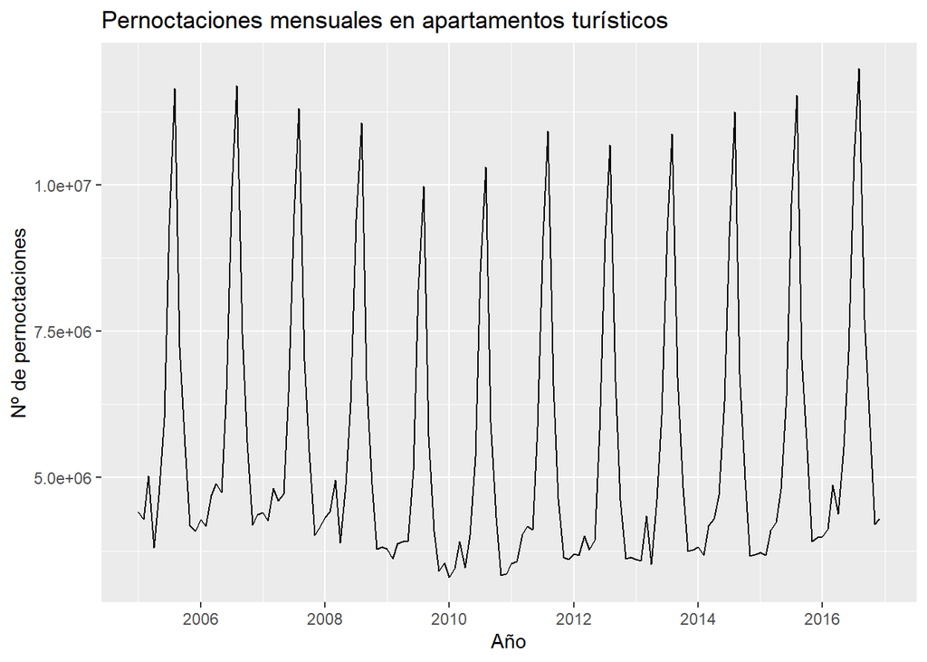

```r
# Serie observada exceptuano el último año
autoplot(pernoctaciones_reserv) + ggtitle("Pernoctaciones mensuales en apartamentos turísticos") + xlab("Año") + ylab("Nº de pernoctaciones")
```

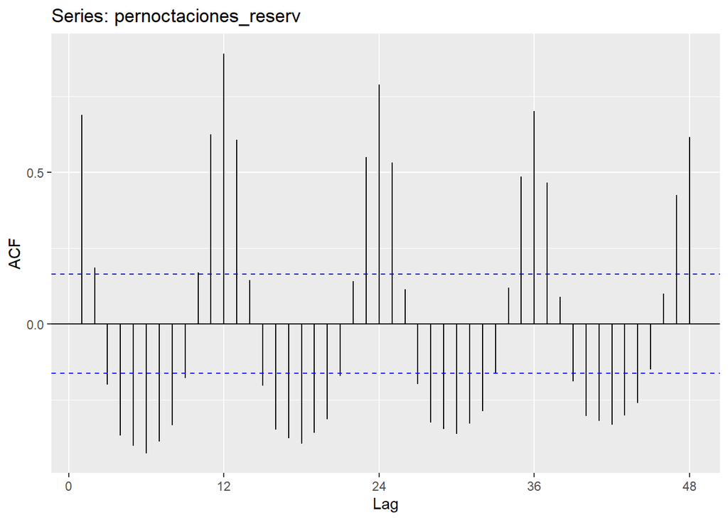

```r
# Autocorrelograma simple
ggAcf(pernoctaciones_reserv, lag = 48)
```

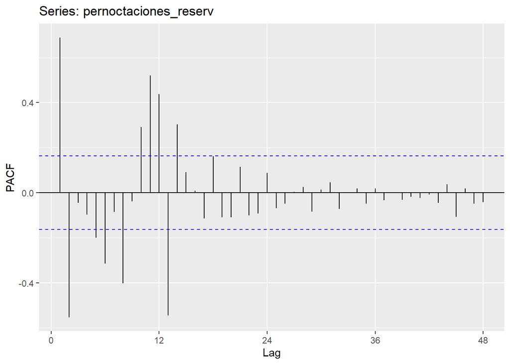

```r
# Autocorrelograma parcial
ggPacf(pernoctaciones_reserv, lag = 48)
```

Para obtener el mejor modelo para su ajuste se hace uso de la función auto.arima. La función da como resultado que el modelo a ajustar es el siguiente: $ARIMA(0, 1, 1)(0, 1, 1)_{12}$

Se puede afirmar que los residuales del modelo están incorrelados ya que el p-valor del contraste de Ljung-Box devuelve un valor 0,09851 que es mayor que el nivel de significación de 0,05 y, por tanto, se acepta la hipotesis de la incorrelación de los residuales. Asimismo, en el autocorrelograma simple casi todas las barras están dentro de las bandas de confianza calculadas con un 95% de probabilidad.

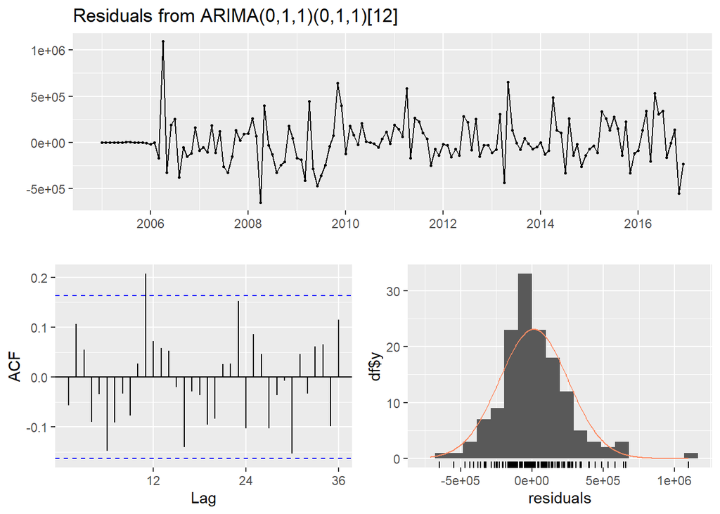

```
##
##  Ljung-Box test
##
## data:  Residuals from ARIMA(0,1,1)(0,1,1)[12]
## Q* = 30.884, df = 22, p-value = 0.09851
##
## Model df: 2.   Total lags used: 24
```

```r
# Uso de la función auto.arima para ajustar el mejor modelo
fitPernoctaciones1 <- auto.arima(pernoctaciones_reserv, seasonal = TRUE)
checkresiduals(fitPernoctaciones1)
```

Se puede probar un nuevo modelo añadiendo, por ejemplo, valores de autorregresivos en la parte regular y en la parte estacional, por ejemplo: $ARIMA(1, 1, 1)(1, 1, 1)_{12}$

En este caso, se observa que los residuales del modelo están incorrelados puesto que el contraste de Ljung-Box devuelve un p-valor de 0,07636 y mayor al nivel de significación de 0,05.

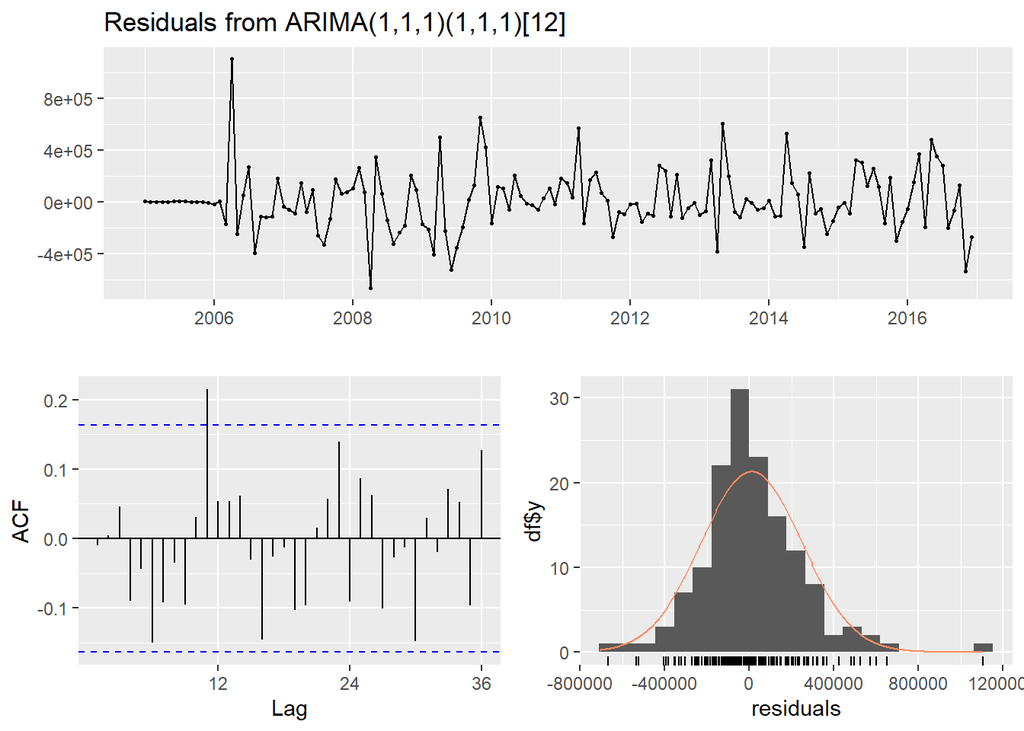

```
##
##  Ljung-Box test
##
## data:  Residuals from ARIMA(1,1,1)(1,1,1)[12]
## Q* = 29.614, df = 20, p-value = 0.07636
##
## Model df: 4.   Total lags used: 24
```

```r
# Un segundo modelo
fitPernoctaciones2 <- Arima(pernoctaciones_reserv, order = c(1,1,1), seasonal = c(1,1,1))
checkresiduals(fitPernoctaciones2)
```

Se pueden comparar los dos modelos para comprobar cuál de los dos tienen un menor valor de los criterios de información, esto es, un menor valor en AIC y BIC. Tal y como se comprueba a continuación, el primer modelo es el que menor valor tiene en los criterios de información y será el que finalmente se ajuste.

```r
print(fitPernoctaciones1)
```

```
## Series: pernoctaciones_reserv
## ARIMA(0,1,1)(0,1,1)[12]
##
## Coefficients:
##           ma1     sma1
##       -0.5007  -0.6774
## s.e.   0.0823   0.1057
##
## sigma^2 = 6.466e+10:  log likelihood = -1819.15
## AIC=3644.31   AICc=3644.5   BIC=3652.93
```

```r
print(fitPernoctaciones2)
```

```
## Series: pernoctaciones_reserv
## ARIMA(1,1,1)(1,1,1)[12]
##
## Coefficients:
##           ar1      ma1    sar1     sma1
##       -0.2741  -0.2766  0.0786  -0.7221
## s.e.   0.1637   0.1717  0.1553   0.1472
##
## sigma^2 = 6.445e+10:  log likelihood = -1818
## AIC=3646   AICc=3646.48   BIC=3660.37
```

Por tanto, se ajustará el modelo obtenido de manera automática mediante la función **auto.arima** y que se trata de: $ARIMA(0, 1, 1)(0, 1, 1)_{12}$

```r
# Valores estimados para el modelo ARIMA
print(fitPernoctaciones1)
```

```
## Series: pernoctaciones_reserv
## ARIMA(0,1,1)(0,1,1)[12]
##
## Coefficients:
##           ma1     sma1
##       -0.5007  -0.6774
## s.e.   0.0823   0.1057
##
## sigma^2 = 6.466e+10:  log likelihood = -1819.15
## AIC=3644.31   AICc=3644.5   BIC=3652.93
```

### 6. Escribir la expresión algebraica del modelo ajustado con los parámetros estimados. (1)

La expresión algebráica del modelo ajustado es: $(1 - B^{12})(1 - B)X_{t} = (1 + \Theta_{1}B^{12})(1 + \theta_{1}B)Z_{t}$

La expresión algebráica del modelo ajustado con los parámetros estimados es: $(1 - B^{12})(1 - B)X_{t} = (1 - 0,6774B^{12})(1 - 0,5007B)Z_{t}$

### 7. Calcular las predicciones y los intervalos de confianza para las unidades de tiempo que se considere oportuno, dependiendo de la serie, siguientes al último valor observado. Representarlas gráficamente. (1)

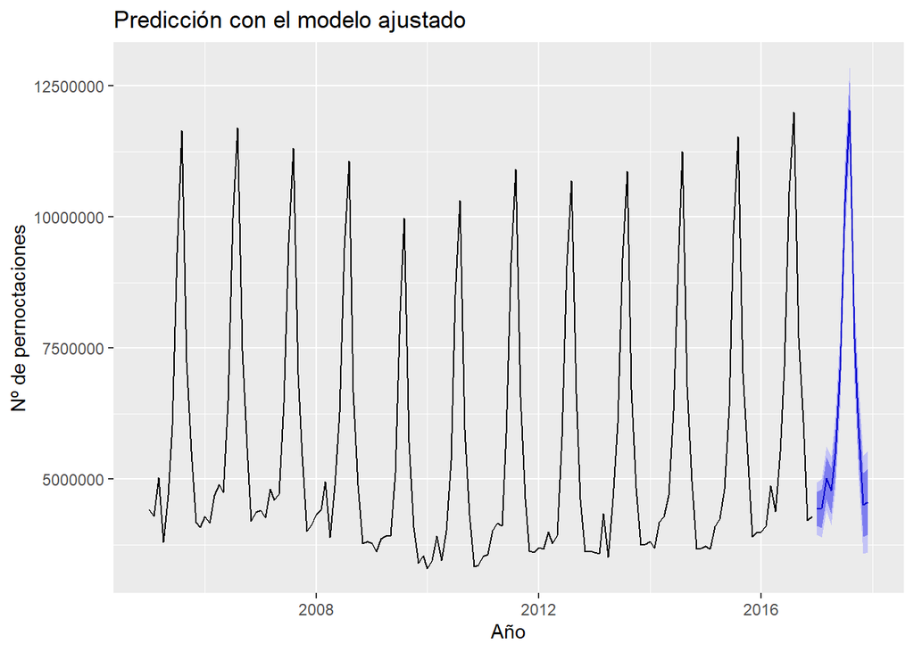

```r
# Predicciones para 12 meses
autoplot(forecast(fitPernoctaciones1, h = 12)) +
  ggtitle("Predicción con el modelo ajustado") + xlab("Año") + ylab("Nº de pernoctaciones")
```

```r
knitr::kable(forecast(fitPernoctaciones1, h = 12), digits = 2, caption = "Predicciones")
```

Predicciones

|  | Point Forecast | Lo 80 | Hi 80 | Lo 95 | Hi 95 |
| --- | --- | --- | --- | --- | --- |
| Jan 2017 | 4436647 | 4110748 | 4762545 | 3938228 | 4935066 |
| Feb 2017 | 4442951 | 4078696 | 4807206 | 3885871 | 5000031 |
| Mar 2017 | 5021143 | 4622203 | 5420084 | 4411016 | 5631270 |
| Apr 2017 | 4779271 | 4348428 | 5210114 | 4120354 | 5438188 |
| May 2017 | 5489629 | 5029089 | 5950169 | 4785293 | 6193964 |
| Jun 2017 | 7082558 | 6594122 | 7570993 | 6335560 | 7829555 |
| Jul 2017 | 10286658 | 9771837 | 10801480 | 9499307 | 11074010 |
| Aug 2017 | 12030180 | 11490260 | 12570099 | 11204444 | 12855915 |
| Sep 2017 | 7685860 | 7121959 | 8249762 | 6823448 | 8548273 |
| Oct 2017 | 5986703 | 5399799 | 6573608 | 5089111 | 6884296 |
| Nov 2017 | 4517692 | 3908653 | 5126731 | 3586247 | 5449137 |
| Dec 2017 | 4571395 | 3940998 | 5201792 | 3607286 | 5535504 |

### 8. Comparar las predicciones obtenidas con cada uno de los métodos con los valores observados que habíamos reservado antes. Conclusiones. (0.5)

A continuación se representan la serie observada, la serie de la predicción realizada con la función **auto.arima** y la serie obtenida añadiendo valores en los autorregresivos y medias moviles de la parte regular y la parte estacional a partir del modelo anterior. El modelo que se ha decidido finalmente ajustar es el modelo obtenido con la función **auto.arima** que tiene sus valores residuales incorrelados. Se observa que los valores observados que se habían reservado anteriormente, se encuentran dentro del intervalo de predicción que proporciona el modelo que finalmente se ha ajustado y que en el gráfico se corresponde con la serie roja.

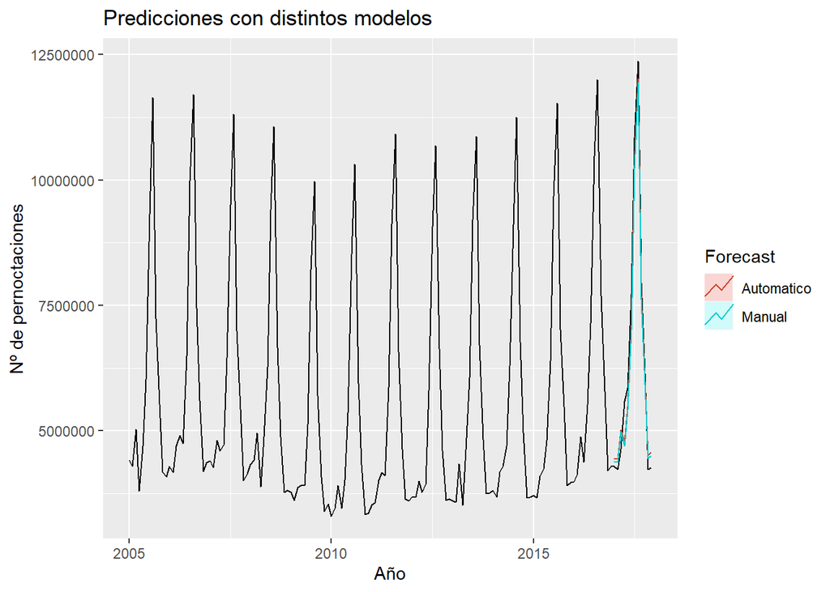

```r
# Comparaciones
autoplot(pernoctaciones) +
  autolayer(forecast(fitPernoctaciones1, h = 12), series = "Automatico", PI = FALSE) +
  autolayer(forecast(fitPernoctaciones2, h = 12), series = "Manual", PI = FALSE) +
  ggtitle("Predicciones con distintos modelos") + xlab("Año") + ylab("Nº de pernoctaciones") +
  guides(colour = guide_legend(title = "Forecast"))
```